# World Cup Betting Studies

Analyses reported in the paper (Round of 16, 8 matches; Quarterfinals, 4 matches), plus new analyses

# Methods

## Matchups, Odds, and Advancing Teams

Matchups, Odds, and Advancing Teams for Round of 16 and Quarterfinals

| Favorites Team | Favorites Odds | Favorites Outcome | Underdogs Team | Underdogs Odds | Underdogs Outcome |
| --- | --- | --- | --- | --- | --- |
| **Round of 16** |  |  |  |  |  |
| Argentina | -750 | Advanced | Egypt | +500 |  |
| Brazil | -230 |  | Norway | +185 | Advanced |
| Colombia | -160 |  | Switzerland | +130 | Advanced |
| England | -135 | Advanced | Mexico | +105 |  |
| France | -1600 | Advanced | Paraguay | +800 |  |
| Morocco | -265 | Advanced | Canada | +210 |  |
| Spain | -220 | Advanced | Portugal | +175 |  |
| USA | -110 |  | Belgium | -110 | Advanced |
| **Quarterfinals** |  |  |  |  |  |
| Argentina | -275 | Advanced | Switzerland | +215 |  |
| France | -370 | Advanced | Morocco | +285 |  |
| England | -215 | Advanced | Norway | +170 |  |
| Spain | -340 | Advanced | Belgium | +260 |  |

## Participant Information

Completion Time and Bonus Payments

|  | Round of 16 | Quarterfinals |
| --- | --- | --- |
| Median completion time (min:sec) | 7:59 | 5:44 |
| Completion time IQR (min:sec) | 6:00 to 10:44 | 4:14 to 7:54 |
| Received a bonus (%) | 24.6 | 50.3 |
| Mean bonus among recipients | 19 cents | 27 cents |

Summary of Demographic Information, Sports Betting Experience, and Soccer Watching Experience by Sample

| Variable | Level | Round of 16 sample N | Round of 16 sample % | Quarterfinal sample N | Quarterfinal sample % |
| --- | --- | --- | --- | --- | --- |
| Sample Size |  | 501 |  | 501 |  |
| Gender | Female | 256 | 51.1% | 252 | 50.3% |
|  | Male | 239 | 47.7% | 244 | 48.7% |
|  | Other | 6 | 1.2% | 5 | 1.0% |
| Race/Ethnicity | White (Non-Hispanic) | 251 | 50.1% | 239 | 47.7% |
|  | White (Hispanic) | 97 | 19.4% | 107 | 21.4% |
|  | African American or Black | 70 | 14.0% | 66 | 13.2% |
|  | East Asian | 31 | 6.2% | 28 | 5.6% |
|  | Non-White Hispanic | 19 | 3.8% | 23 | 4.6% |
|  | Other | 33 | 6.6% | 35 | 7.0% |
| Subjective Financial Wellbeing | I am financially well-off | 12 | 2.4% | 9 | 1.8% |
|  | I am financially comfortable | 91 | 18.2% | 74 | 14.8% |
|  | I am somewhat financially comfortable | 114 | 22.8% | 105 | 21.0% |
|  | I have a little left over after basic needs | 141 | 28.1% | 136 | 27.1% |
|  | I can just meet basic needs | 92 | 18.4% | 115 | 23.0% |
|  | I struggle to meet basic needs | 45 | 9.0% | 52 | 10.4% |
|  | I cannot meet basic needs | 6 | 1.2% | 10 | 2.0% |
| Education | Doctorate or Professional degree | 30 | 6.0% | 30 | 6.0% |
|  | Masters degree | 74 | 14.8% | 67 | 13.4% |
|  | Bachelor's or 4 year degree | 204 | 40.7% | 195 | 38.9% |
|  | Associate degree | 41 | 8.2% | 46 | 9.2% |
|  | Some college, no degree | 97 | 19.4% | 107 | 21.4% |
|  | High school graduate or equivalent | 52 | 10.4% | 55 | 11.0% |
|  | Less than High School (no diploma) | 3 | 0.6% | 1 | 0.2% |
| Betting Experience | No experience: I have never placed a sports bet and/or know nothing about sports betting | 190 | 37.9% | 196 | 39.1% |
|  | Beginner: I have bet a few times and/or am not very familiar with sports betting | 155 | 30.9% | 150 | 29.9% |
|  | Intermediate: I bet occasionally and/or understand the basics | 95 | 19.0% | 94 | 18.8% |
|  | Experienced: I bet regularly and/or am comfortable with a wide range of sports bets | 52 | 10.4% | 48 | 9.6% |
|  | Expert: I bet frequently and/or consider myself highly knowledgeable about sports betting | 9 | 1.8% | 13 | 2.6% |
| Soccer Experience | I do not follow soccer at all | 109 | 21.8% | 126 | 25.1% |
|  | I watch occasionally, mainly for major tournaments like the World Cup | 222 | 44.3% | 245 | 48.9% |
|  | I follow one or more leagues casually and watch when convenient | 67 | 13.4% | 63 | 12.6% |
|  | I am an engaged fan who regularly follows teams, results, and standings | 60 | 12.0% | 41 | 8.2% |
|  | I am a dedicated fan who watches most matches and closely follows the sport | 43 | 8.6% | 26 | 5.2% |
| Age | Mean (SD) | 45.0 (15.7) |  | 45.1 (15.5) |  |

# Results

## Probability Estimates and Brier Scores

Mean (SD) Probability Estimates of the Sportsbook Favorite Advancing by Odds Condition

| Match | Sportsbook Favorite | Anchored (SD) | Unanchored (SD) | t | df | Holm p | d |
| --- | --- | --- | --- | --- | --- | --- | --- |
| **Round of 16** |  |  |  |  |  |  |  |
| Argentina vs. Egypt | Argentina | .76 (.22) | .74 (.18) | 1.18 | 456 | .95 | .11 |
| Brazil vs. Norway | Brazil | .66 (.19) | .68 (.18) | -0.74 | 489 | 1.00 | -.07 |
| Switzerland vs. Colombia | Colombia | .58 (.17) | .59 (.18) | -0.65 | 496 | 1.00 | -.06 |
| Mexico vs. England | England | .54 (.18) | .50 (.23) | 2.40 | 490 | .17 | .21 |
| Paraguay vs. France | France | .76 (.27) | .68 (.23) | 3.46 | 468 | .01 | .31 |
| Canada vs. Morocco | Morocco | .61 (.21) | .57 (.19) | 2.15 | 482 | .19 | .19 |
| Portugal vs. Spain | Spain | .59 (.21) | .55 (.20) | 2.38 | 491 | .17 | .21 |
| USA vs. Belgium | USA | .56 (.19) | .60 (.19) | -2.32 | 497 | .17 | -.21 |
| **Quarterfinals** |  |  |  |  |  |  |  |
| Argentina vs. Switzerland | Argentina | .67 (.20) | .71 (.17) | -2.34 | 450 | .17 | -.21 |
| France vs. Morocco | France | .67 (.24) | .64 (.21) | 1.64 | 457 | .51 | .15 |
| Norway vs. England | England | .54 (.20) | .54 (.19) | -0.08 | 480 | 1.00 | -.01 |
| Spain vs. Belgium | Spain | .65 (.22) | .60 (.19) | 2.65 | 454 | .09 | .24 |

Note: Anchored = odds shown while estimating probabilities (Early Odds); unanchored = odds shown only when betting (Late Odds). The underdog's probability is 1 - p(favorite) with the same SD. t and d compare anchored minus unanchored; Welch t-tests, Holm correction across the 12 matches.

Anchored vs. Unanchored Differences in Brier Score and Its Components (Anchored minus Unanchored)

| Sample | Anchored M (SD) | Unanchored M (SD) | t | df | p | d | Collective error diff. (95% CI) | Dispersion diff. (95% CI) |
| --- | --- | --- | --- | --- | --- | --- | --- | --- |
| Round of 16 | .259 (.093) | .286 (.096) | -3.18 | 497 | .002 | -.28 | -.030 (-.043, -.017) | .003 (-.005, .010) |
| Quarterfinals | .185 (.144) | .184 (.105) | 0.04 | 405 | .970 | .00 | -.009 (-.026, .012) | .009 (.001, .018) |

Summary of Brier Scores (Brier Score Decomposition, 95% Cluster Bootstrap CI)

|  | Round of 16 Anchored | Round of 16 Unanchored | Quarterfinals Anchored | Quarterfinals Unanchored |
| --- | --- | --- | --- | --- |
| **Brier Score Decomposition** |  |  |  |  |
| Participants' Brier score (SD) | .259 (.093) | .286 (.096) | .185 (.144) | .184 (.105) |
| Collective error (95% CI) | .217 (.209, .225) | .247 (.236, .256) | .138 (.125, .155) | .147 (.135, .158) |
| Dispersion (95% CI) | .043 (.036, .048) | .039 (.035, .044) | .047 (.040, .054) | .037 (.033, .042) |
| **Mean Brier Scores Using Different Probability Estimation Strategies** |  |  |  |  |
| Always say 50/50 | .250 | .250 | .250 | .250 |
| Always back the sportsbook favorite with certainty | .375 | .375 | .000 | .000 |
| Sportsbook implied probability (vig removed) | .187 | .187 | .087 | .087 |
| Participants beating the sportsbook | 18.1% | 9.9% | 23.7% | 17.9% |

Note: The always-back-the-sportsbook-favorite strategy counts the U.S. as the favorite against Belgium.

Correlations of Participants' Brier Scores With Betting Outcomes, r [95% CI]

|  | Round of 16 Anchored | Round of 16 Unanchored | Quarterfinals Anchored | Quarterfinals Unanchored |
| --- | --- | --- | --- | --- |
| Final token balance | -.37 [-.48, -.26] | -.39 [-.49, -.29] | -.53 [-.62, -.43] | -.43 [-.52, -.33] |
| Number of bets won | -.48 [-.57, -.38] | -.42 [-.52, -.32] | -.60 [-.68, -.51] | -.54 [-.62, -.45] |

## Expected Value

Mean (SD) Expected Value of Each Team by Odds Condition

| Sportsbook Favorites Team | Sportsbook Favorites Anchored | Sportsbook Favorites Unanchored | Sportsbook Underdogs Team | Sportsbook Underdogs Anchored | Sportsbook Underdogs Unanchored |
| --- | --- | --- | --- | --- | --- |
| **Round of 16** |  |  |  |  |  |
| Argentina | -14.1 (25.0) | -16.5 (20.2) | Egypt | 45.1 (132.2) | 57.8 (106.9) |
| Brazil | -4.7 (27.3) | -2.9 (26.2) | Norway | -4.3 (54.3) | -7.8 (52.1) |
| Colombia | -5.6 (27.9) | -4.0 (28.6) | Switzerland | -3.6 (39.5) | -5.9 (40.4) |
| England | -5.3 (31.3) | -12.9 (39.6) | Mexico | -6.5 (36.8) | 2.5 (46.7) |
| France | -19.7 (29.1) | -28.1 (24.8) | Paraguay | 119.6 (246.2) | 190.6 (210.1) |
| Morocco | -15.8 (28.3) | -21.1 (25.9) | Canada | 20.6 (63.7) | 32.4 (58.3) |
| Spain | -14.0 (30.5) | -20.4 (29.6) | Portugal | 12.4 (57.6) | 24.5 (55.9) |
| USA | 6.3 (35.4) | 13.8 (36.9) | Belgium | -15.4 (35.4) | -22.9 (36.9) |
| **Quarterfinals** |  |  |  |  |  |
| Argentina | -8.7 (27.4) | -3.3 (23.4) | Switzerland | 4.2 (63.2) | -8.3 (54.1) |
| France | -14.6 (30.8) | -18.8 (27.2) | Morocco | 26.0 (93.5) | 39.0 (82.5) |
| England | -21.3 (28.8) | -21.1 (28.3) | Norway | 24.9 (53.0) | 24.5 (52.1) |
| Spain | -15.9 (28.9) | -22.4 (25.2) | Belgium | 26.0 (80.3) | 44.1 (70.0) |

Note: Expected value per 100 tokens, based on each participant's own stated probability and the odds shown.

Expected Value Analyses by Odds Condition

|  | Anchored M (SD) or % | Unanchored M (SD) or % | Anchored vs. Unanchored [95% CI] | p |
| --- | --- | --- | --- | --- |
| **Round of 16** |  |  |  |  |
| Mean team EV (per 100 tokens) | 5.9 (85.5) | 11.2 (86.2) | -5.26 [-8.53, -1.99] | .002 |
| Team evaluations with a positive EV (%) | 41.4 | 44.5 | 0.87 [0.79, 0.96] | .004 |
| Bet on the higher-EV team (%) | 69.0 | 62.4 | 1.53 [1.22, 1.92] | <.001 |
| Discordant matches: participant favorite was not the higher-EV team (%) | 25.2 | 32.0 | 0.59 [0.47, 0.75] | <.001 |
| In discordant matches, bet on the participant favorite (%) | 90.5 | 75.0 | 6.06 [2.37, 15.48] | <.001 |
| **Quarterfinals** |  |  |  |  |
| Mean team EV (per 100 tokens) | 2.6 (59.4) | 4.2 (56.3) | -1.63 [-4.94, 1.68] | .334 |
| Team evaluations with a positive EV (%) | 44.5 | 45.5 | 0.96 [0.84, 1.09] | .502 |
| Bet on the higher-EV team (%) | 66.4 | 62.5 | 1.22 [0.96, 1.56] | .099 |
| Discordant matches: participant favorite was not the higher-EV team (%) | 28.1 | 38.0 | 0.59 [0.46, 0.76] | <.001 |
| In discordant matches, bet on the participant favorite (%) | 84.8 | 73.5 | 2.51 [0.46, 13.57] | .286 |

Note: Mixed models with a participant random intercept and team (first two rows) or match (other rows) fixed effects: linear coefficient (anchored - unanchored) for mean EV, odds ratios for percentages. Participant favorite = team the participant predicted to advance. Match-level rows exclude estimates with equal EVs for the two teams (R16: 148; QF: 0).

## Predicting Betting on the Sportsbook Favorite

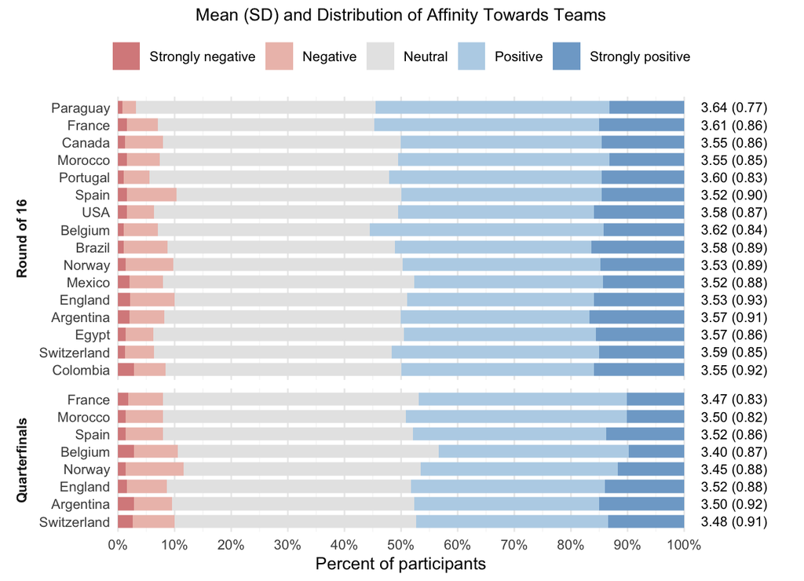

Range Across Teams of the Percent of Participants With Negative, Neutral, and Positive Affinity

| Affinity | Round of 16 | Quarterfinals |
| --- | --- | --- |
| Negative (1-2) | 3.2 - 10.4 | 8.0 - 11.6 |
| Neutral (3) | 37.5 - 44.3 | 41.9 - 46.1 |
| Positive (4-5) | 47.7 - 55.5 | 43.3 - 49.1 |

Percentage of Participants Betting on Each Team and Mean (SD) Tokens Wagered

| Sportsbook Favorites Team | Sportsbook Favorites % Bet on | Sportsbook Favorites Mean Tokens (SD) | Sportsbook Underdogs Team | Sportsbook Underdogs % Bet on | Sportsbook Underdogs Mean Tokens (SD) |
| --- | --- | --- | --- | --- | --- |
| **Round of 16** |  |  |  |  |  |
| Argentina | 84.4% | 11.1 (14.1) | Egypt | 15.6% | 1.7 (5.3) |
| Brazil | 77.2% | 9.2 (13.0) | Norway | 22.8% | 2.2 (6.1) |
| Colombia | 69.3% | 5.8 (8.8) | Switzerland | 30.7% | 2.7 (5.9) |
| England | 56.1% | 5.4 (9.0) | Mexico | 43.9% | 5.6 (11.2) |
| France | 77.2% | 11.6 (16.9) | Paraguay | 22.8% | 3.9 (12.4) |
| Morocco | 66.1% | 5.8 (8.8) | Canada | 33.9% | 3.2 (6.0) |
| Spain | 65.7% | 6.3 (10.0) | Portugal | 34.3% | 3.9 (8.4) |
| USA | 80.2% | 13.4 (18.4) | Belgium | 19.8% | 1.9 (7.1) |
| **Quarterfinals** |  |  |  |  |  |
| Argentina | 77.0% | 18.5 (18.3) | Switzerland | 23.0% | 5.2 (10.7) |
| France | 70.3% | 16.8 (17.0) | Morocco | 29.7% | 6.8 (12.3) |
| England | 53.9% | 11.4 (15.8) | Norway | 46.1% | 13.0 (19.0) |
| Spain | 67.9% | 14.3 (14.7) | Belgium | 32.1% | 7.3 (13.5) |

Note: Tokens are coded as 0 for the team not bet on in a match. % Bet on is based on the Block 3 bet choice; tokens are based on the final bet.

Repeated-Measures Correlations Among Betting Variables (Round of 16 Below the Diagonal, Quarterfinals Above)

| Variable | 1 | 2 | 3 | 4 | 5 | 6 |
| --- | --- | --- | --- | --- | --- | --- |
| 1. Bet on sportsbook favorite (0/1) | - | .59* | .51* | .47* | -.02 | .02 |
| 2. Participant favorite = sportsbook favorite (0/1) | .60* | - | .72* | .69* | -.02 | -.01 |
| 3. Probability of sportsbook favorite | .48* | .70* | - | .95* | .10* | -.01 |
| 4. EV difference (fav - dog) | .29* | .45* | .61* | - | .34* | -.01 |
| 5. SD difference (fav - dog) | -.06* | -.08* | -.14* | .61* | - | .01 |
| 6. Affinity difference (fav - dog) | .00 | .00 | .00 | -.01 | -.01 | - |

Note: Correlations remove each participant's own mean from both variables and pool across participants (repeated-measures correlation). Correlations with variables 1 and 2 are point-biserial. * p < .05, Holm-corrected across the 15 pairs within each sample.

Single-Predictor Mixed-Effects Logistic Regressions Predicting a Bet on the Sportsbook Favorite, Round of 16 (Odds Ratios per 1 SD)

|  | Probability |  |  | EV difference |  |  | SD difference |  |  | Affinity difference |  |  |
| --- | --- | --- | --- | --- | --- | --- | --- | --- | --- | --- | --- | --- |
| Predictors | OR | 95% CI | p | OR | 95% CI | p | OR | 95% CI | p | OR | 95% CI | p |
| Intercept | 5.32 | 4.42 – 6.40 | **<0.001** | 3.55 | 3.08 – 4.08 | **<0.001** | 3.34 | 2.92 – 3.83 | **<0.001** | 3.33 | 2.91 – 3.81 | **<0.001** |
| Probability of sportsbook favorite | 6.08 | 5.22 – 7.08 | **<0.001** |  |  |  |  |  |  |  |  |  |
| EV difference (fav - dog) |  |  |  | 2.44 | 2.20 – 2.70 | **<0.001** |  |  |  |  |  |  |
| SD difference (fav - dog) |  |  |  |  |  |  | 0.89 | 0.82 – 0.96 | **0.003** |  |  |  |
| Affinity difference (fav - dog) |  |  |  |  |  |  |  |  |  | 0.99 | 0.91 – 1.07 | 0.820 |
| Random Effects |  |  |  |  |  |  |  |  |  |  |  |  |
| σ<sup>2</sup> | 3.29 |  |  | 3.29 |  |  | 3.29 |  |  | 3.29 |  |  |
| τ<sub>00</sub> | 2.24 <sub>ProlificID</sub> |  |  | 1.39 <sub>ProlificID</sub> |  |  | 1.46 <sub>ProlificID</sub> |  |  | 1.43 <sub>ProlificID</sub> |  |  |
| ICC | 0.41 |  |  | 0.30 |  |  | 0.31 |  |  | 0.30 |  |  |
| N | 501 <sub>ProlificID</sub> |  |  | 501 <sub>ProlificID</sub> |  |  | 501 <sub>ProlificID</sub> |  |  | 501 <sub>ProlificID</sub> |  |  |
| Observations | 4008 |  |  | 4008 |  |  | 4008 |  |  | 4008 |  |  |
| Marginal R<sup>2</sup> / Conditional R<sup>2</sup> | 0.371 / 0.626 |  |  | 0.145 / 0.399 |  |  | 0.003 / 0.310 |  |  | 0.000 / 0.303 |  |  |
| AIC | 3372.111 |  |  | 4027.323 |  |  | 4402.524 |  |  | 4411.060 |  |  |

Single-Predictor Mixed-Effects Logistic Regressions Predicting a Bet on the Sportsbook Favorite, Quarterfinals (Odds Ratios per 1 SD)

|  | Probability |  |  | EV difference |  |  | SD difference |  |  | Affinity difference |  |  |
| --- | --- | --- | --- | --- | --- | --- | --- | --- | --- | --- | --- | --- |
| Predictors | OR | 95% CI | p | OR | 95% CI | p | OR | 95% CI | p | OR | 95% CI | p |
| Intercept | 4.64 | 3.53 – 6.10 | **<0.001** | 4.02 | 3.14 – 5.15 | **<0.001** | 2.92 | 2.39 – 3.56 | **<0.001** | 2.92 | 2.39 – 3.57 | **<0.001** |
| Probability of sportsbook favorite | 9.31 | 7.10 – 12.21 | **<0.001** |  |  |  |  |  |  |  |  |  |
| EV difference (fav - dog) |  |  |  | 7.23 | 5.68 – 9.20 | **<0.001** |  |  |  |  |  |  |
| SD difference (fav - dog) |  |  |  |  |  |  | 1.07 | 0.94 – 1.21 | 0.310 |  |  |  |
| Affinity difference (fav - dog) |  |  |  |  |  |  |  |  |  | 0.99 | 0.88 – 1.13 | 0.935 |
| Random Effects |  |  |  |  |  |  |  |  |  |  |  |  |
| σ<sup>2</sup> | 3.29 |  |  | 3.29 |  |  | 3.29 |  |  | 3.29 |  |  |
| τ<sub>00</sub> | 4.00 <sub>ProlificID</sub> |  |  | 3.31 <sub>ProlificID</sub> |  |  | 2.57 <sub>ProlificID</sub> |  |  | 2.61 <sub>ProlificID</sub> |  |  |
| ICC | 0.55 |  |  | 0.50 |  |  | 0.44 |  |  | 0.44 |  |  |
| N | 501 <sub>ProlificID</sub> |  |  | 501 <sub>ProlificID</sub> |  |  | 501 <sub>ProlificID</sub> |  |  | 501 <sub>ProlificID</sub> |  |  |
| Observations | 2004 |  |  | 2004 |  |  | 2004 |  |  | 2004 |  |  |
| Marginal R<sup>2</sup> / Conditional R<sup>2</sup> | 0.406 / 0.732 |  |  | 0.372 / 0.687 |  |  | 0.001 / 0.439 |  |  | 0.000 / 0.443 |  |  |
| AIC | 1714.441 |  |  | 1790.844 |  |  | 2323.362 |  |  | 2324.382 |  |  |

Single-Predictor Mixed-Effects Logistic Regressions Predicting a Bet on the Sportsbook Favorite

| Predictor | OR [95% CI] | p | Marginal R2 | % Classified |
| --- | --- | --- | --- | --- |
| **Round of 16** |  |  |  |  |
| Probability of sportsbook favorite | 6.08 [5.22, 7.08] | <.001 | .371 | 79.7 |
| EV difference (fav - dog) | 2.44 [2.20, 2.70] | <.001 | .145 | 72.6 |
| SD difference (fav - dog) | 0.89 [0.82, 0.96] | .003 | .003 | 72.0 |
| Affinity difference (fav - dog) | 0.99 [0.91, 1.07] | .820 | .000 | 72.0 |
| **Quarterfinals** |  |  |  |  |
| Probability of sportsbook favorite | 9.31 [7.10, 12.21] | <.001 | .406 | 78.1 |
| EV difference (fav - dog) | 7.23 [5.68, 9.20] | <.001 | .372 | 77.1 |
| SD difference (fav - dog) | 1.07 [0.94, 1.21] | .310 | .001 | 67.3 |
| Affinity difference (fav - dog) | 0.99 [0.88, 1.13] | .935 | .000 | 67.3 |

Note: Each row is a separate model with a participant random intercept. Odds ratios are per 1 SD. % Classified = bets correctly classified from the fixed effects; always predicting a bet on the sportsbook favorite classifies 72.0% (Round of 16) and 67.3% (Quarterfinals).

Mixed-Effects Logistic Regression Predicting a Bet on the Sportsbook Favorite From All Predictors

|  | Round of 16 |  |  | Quarterfinals |  |  |
| --- | --- | --- | --- | --- | --- | --- |
| Predictors | OR | 95% CI | p | OR | 95% CI | p |
| Intercept | 0.27 | 0.20 – 0.38 | **<0.001** | 0.27 | 0.15 – 0.48 | **<0.001** |
| Participant favorite = sportsbook favorite (0/1) | 32.38 | 22.95 – 45.69 | **<0.001** | 29.62 | 15.34 – 57.20 | **<0.001** |
| EV difference (fav - dog) | 1.61 | 1.32 – 1.96 | **<0.001** | 2.98 | 2.11 – 4.21 | **<0.001** |
| SD difference (fav - dog) | 0.72 | 0.61 – 0.85 | **<0.001** | 0.70 | 0.56 – 0.87 | **0.001** |
| Affinity difference (fav - dog) | 0.99 | 0.89 – 1.10 | 0.867 | 1.05 | 0.89 – 1.25 | 0.541 |
| Odds condition (anchored = 1) | 2.13 | 1.50 – 3.03 | **<0.001** | 1.99 | 1.20 – 3.31 | **0.008** |
| Random Effects |  |  |  |  |  |  |
| σ<sup>2</sup> | 3.29 |  |  | 3.29 |  |  |
| τ<sub>00</sub> | 2.43 <sub>ProlificID</sub> |  |  | 4.82 <sub>ProlificID</sub> |  |  |
| ICC | 0.42 |  |  | 0.59 |  |  |
| N | 501 <sub>ProlificID</sub> |  |  | 501 <sub>ProlificID</sub> |  |  |
| Observations | 4008 |  |  | 2004 |  |  |
| Marginal R<sup>2</sup> / Conditional R<sup>2</sup> | 0.372 / 0.639 |  |  | 0.410 / 0.760 |  |  |
| AIC | 3040.618 |  |  | 1582.425 |  |  |

Combined Mixed-Effects Logistic Regression Predicting a Bet on the Sportsbook Favorite: Coefficients, Collinearity, and Relative Importance

| Predictor | OR [95% CI] | p | VIF | Dominance (%) |
| --- | --- | --- | --- | --- |
| **Round of 16** |  |  |  |  |
| Participant favorite = sportsbook favorite (0/1) | 32.38 [22.95, 45.69] | <.001 | 1.78 | 54.6 |
| EV difference (fav - dog) | 1.61 [1.32, 1.96] | <.001 | 2.71 | 30.5 |
| SD difference (fav - dog) | 0.72 [0.61, 0.85] | <.001 | 2.02 | 10.8 |
| Affinity difference (fav - dog) | 0.99 [0.89, 1.10] | .867 | 1.00 | 0.0 |
| Odds condition (anchored = 1) | 2.13 [1.50, 3.03] | <.001 | 1.00 | 4.2 |
| **Quarterfinals** |  |  |  |  |
| Participant favorite = sportsbook favorite (0/1) | 29.62 [15.34, 57.20] | <.001 | 2.45 | 45.1 |
| EV difference (fav - dog) | 2.98 [2.11, 4.21] | <.001 | 2.89 | 51.0 |
| SD difference (fav - dog) | 0.70 [0.56, 0.87] | .001 | 1.37 | 2.2 |
| Affinity difference (fav - dog) | 1.05 [0.89, 1.25] | .541 | 1.00 | 0.0 |
| Odds condition (anchored = 1) | 1.99 [1.20, 3.31] | .008 | 1.01 | 1.7 |

Note: Participant random intercept. The participant-favorite odds ratio compares participants whose predicted team was the sportsbook favorite with those who predicted the underdog; the odds-condition odds ratio compares anchored with unanchored participants; other odds ratios are per 1 SD. Dominance (%) = general dominance weight as a percentage of the model's marginal R2 (R16 = .372; QF = .410). The full model classifies 83.8% (R16) and 82.9% (QF) of bets correctly; the participant favorite alone classifies 83.8% and 82.9%.

Bets on the Sportsbook Favorite by Participant Favorite and Higher-EV Team

| Participant Favorite | Higher-EV Team | n (% of Matches) | Bet on Sportsbook Favorite | Bet on Sportsbook Underdog |
| --- | --- | --- | --- | --- |
| **Round of 16** |  |  |  |  |
| Sportsbook favorite | Sportsbook favorite | 1762 (45.6%) | 1596 (90.6%) | 166 (9.4%) |
| Sportsbook favorite | Sportsbook underdog | 1112 (28.8%) | 905 (81.4%) | 207 (18.6%) |
| Sportsbook underdog | Sportsbook underdog | 986 (25.5%) | 260 (26.4%) | 726 (73.6%) |
| Total |  | 3860 | 2761 (71.5%) | 1099 (28.5%) |
| **Quarterfinals** |  |  |  |  |
| Sportsbook favorite | Sportsbook favorite | 808 (40.3%) | 720 (89.1%) | 88 (10.9%) |
| Sportsbook favorite | Sportsbook underdog | 671 (33.5%) | 522 (77.8%) | 149 (22.2%) |
| Sportsbook underdog | Sportsbook underdog | 525 (26.2%) | 106 (20.2%) | 419 (79.8%) |
| Total |  | 2004 | 1348 (67.3%) | 656 (32.7%) |

Note: Cells are n of participant x match observations; percentages in the bet columns are of the row. Participant favorite = team the participant predicted to advance; higher-EV team is based on the participant's own probability. Estimates with equal EVs for the two teams are excluded (R16: 148; QF: 0). No participant favorite that was the sportsbook underdog had the lower EV (empty row omitted).

## Distribution of Bet Amounts

Normalized HHI of Token Allocation

|  | Round of 16 | Quarterfinals |
| --- | --- | --- |
| Participants who bet no tokens (excluded) | 5 | 5 |
| Bettors (n) | 496 | 496 |
| Normalized HHI, mean | .18 | .13 |
| Normalized HHI, SD | .27 | .23 |
| Normalized HHI, median | .07 | .04 |
| Mean normalized HHI of a strategy of half the tokens on one match, rest spread evenly | .18 | .11 |
| Bettors who bet on only one match (%) | 7.1 | 4.8 |

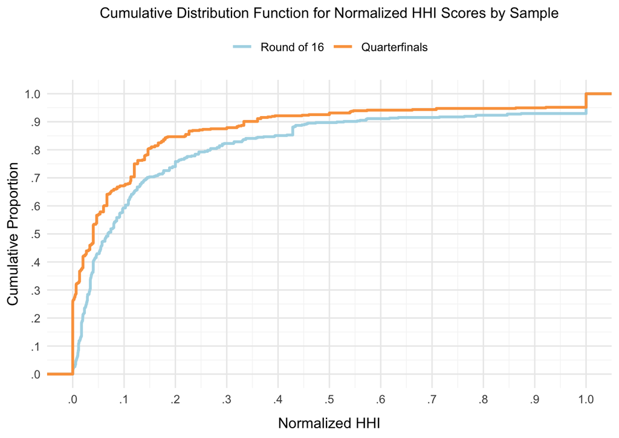

Summary of Bet Amount Distribution Group Characteristics and Performance

| Group | Round of 16 Sample N | Round of 16 Sample HHI Norm (SD) | Round of 16 Sample Proportion of Matches Bet On (SD) | Quarterfinals Sample N | Quarterfinals Sample HHI Norm (SD) | Quarterfinals Sample Proportion of Matches Bet On (SD) |
| --- | --- | --- | --- | --- | --- | --- |
| Spreaders | 372 | .08 (.13) | .96 (.08) | 439 | .07 (.11) | 1.00 (.00) |
| Selectors | 86 | .26 (.13) | .47 (.15) | 31 | .28 (.14) | .66 (.12) |
| Concentrators | 38 | .98 (.07) | .13 (.03) | 26 | .98 (.06) | .27 (.07) |
| Group | Brier Scores (SD) | Final Tokens (SD) | % of Matches Correctly Predicted (SD) | Brier Scores (SD) | Final Tokens (SD) | % of Matches Correctly Predicted (SD) |
| Spreaders | .273 (.093) | 76.0 (31.4) | 54.0 (16.7) | .190 (.125) | 88.3 (45.5) | 72.6 (28.2) |
| Selectors | .255 (.086) | 74.7 (48.2) | 56.0 (16.0) | .162 (.107) | 85.0 (53.9) | 78.2 (27.2) |
| Concentrators | .314 (.125) | 50.4 (62.0) | 49.7 (19.6) | .128 (.097) | 92.8 (62.8) | 87.5 (14.6) |

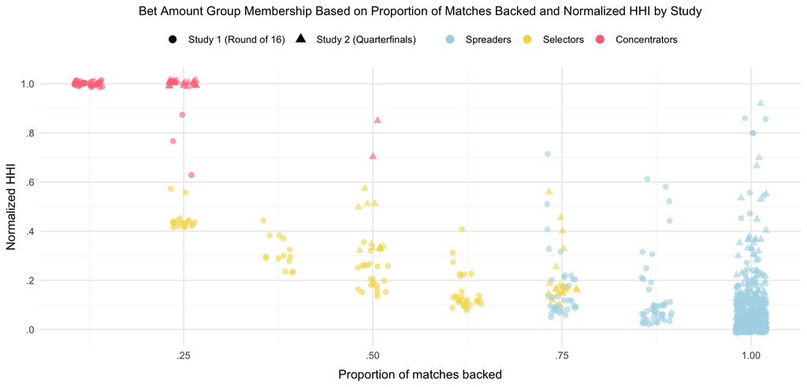

One-Way ANOVAs of Group on Betting Performance, by Sample

| Dependent variable | F | df | p | Partial eta-squared |
| --- | --- | --- | --- | --- |
| **Study 1 (Round of 16)** |  |  |  |  |
| % of matches correctly predicted | 1.84 | 2, 493 | .160 | .007 |
| Final tokens | 7.86 | 2, 493 | <.001 | .031 |
| Brier score | 5.19 | 2, 493 | .006 | .021 |
| **Study 2 (Quarterfinals)** |  |  |  |  |
| % of matches correctly predicted | 4.02 | 2, 493 | .019 | .016 |
| Final tokens | 0.19 | 2, 493 | .824 | .001 |
| Brier score | 3.68 | 2, 493 | .026 | .015 |

Games-Howell Post Hoc Comparisons Between Groups

| Comparison | Mean difference | Adjusted p | d |
| --- | --- | --- | --- |
| **Study 1 (Round of 16): Final tokens** |  |  |  |
| Spreaders - Selectors | 1.3 | .970 | .04 |
| Spreaders - Concentrators | 25.5 | .043 | .72 |
| Selectors - Concentrators | 24.2 | .090 | .46 |
| **Study 1 (Round of 16): Brier score** |  |  |  |
| Spreaders - Selectors | .018 | .184 | .20 |
| Spreaders - Concentrators | -.041 | .133 | -.42 |
| Selectors - Concentrators | -.059 | .027 | -.60 |
| **Study 2 (Quarterfinals): % of matches correctly predicted** |  |  |  |
| Spreaders - Selectors | -5.6 | .515 | -.20 |
| Spreaders - Concentrators | -14.9 | <.001 | -.54 |
| Selectors - Concentrators | -9.3 | .240 | -.41 |
| **Study 2 (Quarterfinals): Brier score** |  |  |  |
| Spreaders - Selectors | .028 | .366 | .22 |
| Spreaders - Concentrators | .062 | .011 | .50 |
| Selectors - Concentrators | .034 | .420 | .33 |

### Tokens on the Participant Favorite vs. the Higher-EV Team

Two versions of the same comparison are given below (Option A and Option B); keep one.

Option A: Tokens Wagered in Discordant Matches on the Participant Favorite vs. the Higher-EV Team

|  | Round of 16 | Quarterfinals |
| --- | --- | --- |
| Bets on the participant favorite, n | 690 | 472 |
| Bets on the higher-EV team, n | 181 | 151 |
| Participants, n | 351 | 336 |
| Tokens per bet on the participant favorite, M (SD) | 13.1 (10.8) | 22.6 (12.4) |
| Tokens per bet on the higher-EV team, M (SD) | 12.8 (10.7) | 21.8 (13.4) |
| Share of discordant-match tokens on the participant favorite (%) | 79.5 | 76.4 |
| Difference (higher-EV - participant favorite) [95% CI] | -0.2 [-2.1, 1.7] | -1.1 [-3.5, 1.3] |
| t (df) | -0.23 (653) | -0.89 (538) |
| p | .822 | .376 |

Note: Discordant matches = the team the participant predicted to advance was not the higher-EV team (from the participant's own probability). Bets of 0 tokens are excluded. The difference is from a linear mixed model of tokens per bet with a participant random intercept (Satterthwaite df).

Option B: Total Tokens Wagered on Participant Favorites vs. Higher-EV Teams Across All Matches

|  | Round of 16 | Quarterfinals |
| --- | --- | --- |
| Participants who wagered tokens, n | 494 | 496 |
| Total tokens on participant favorites, M (SD) | 78.0 (26.0) | 79.3 (28.7) |
| Total tokens on higher-EV teams, M (SD) | 64.4 (29.2) | 64.4 (31.6) |
| Share of wagered tokens on participant favorites (%) | 85.5 | 84.3 |
| Share of wagered tokens on higher-EV teams (%) | 70.6 | 68.4 |
| Participants placing more tokens on participant favorites (%) | 55.9 | 51.4 |
| Participants placing more tokens on higher-EV teams (%) | 13.4 | 15.9 |
| Difference (higher-EV - participant favorite) [95% CI] | -13.6 [-15.9, -11.2] | -14.9 [-17.9, -11.9] |
| t (df) | -11.22 (493) | -9.76 (495) |
| p | <.001 | <.001 |
| dz | -.50 | -.44 |

Note: Totals per participant across all matches (tokens are 0 for a team not backed). In matches where the participant favorite was the higher-EV team, the same tokens count toward both totals. Matches with equal EVs are excluded. Paired t-test across participants.

## Expected Utility

The EV analyses assume that participants were indifferent to risk. In every discordant match, the participant favorite was the sportsbook favorite: the bet with the higher probability of winning and the smaller payoff. A risk-averse bettor could therefore prefer the participant favorite even though the sportsbook underdog had the higher EV. As a supplemental analysis, we asked whether expected utility (EU) predicts participants’ Block 3 choices better than EV and whether risk aversion accounts for their preference for the predicted winner.

Each Block 3 choice is a binary preference between two gambles: a 100-token bet on either team, which returns 100 tokens plus the profit with the participant’s stated probability *p* and nothing otherwise. We used an exponential utility function (Clemen & Reilly, 2014) scaled so that the worst outcome (0 tokens) has utility 0 and the best (900 tokens) has utility 1:

$$u_c(x) = \frac{1 - e^{-c x / 900}}{1 - e^{-c}},$$

where *c* > 0 indicates risk aversion, *c* < 0 risk seeking, and *c* → 0 risk neutrality, in which case EU equals EV. The function is the same as *u*(*x*) = 1 - e<sup>-*x*/*R*</sup> with risk tolerance *R* = 900/*c* tokens, up to a constant that does not change any choice. Because *u*(0) = 0, the EU of a bet is *p* · *u<sub>c</sub>*(100 + profit), and EU predicts the team with the larger value. We applied 120 utility curves, *c* = -6 to 6 in steps of 0.1 (excluding 0), each to every participant. Because no parameter is fit to a participant, a curve can predict choices worse than EV. A choice was counted as correctly predicted if the chosen bet had the higher EU; a 50% estimate for the U.S. against Belgium gives two identical bets and is consistent with every curve. As *c* increases, *u<sub>c</sub>*(*x*) approaches 1 for any winning outcome, so EU depends only on the probability of winning and predicts a bet on the predicted winner. Appendix B relates each *c* to a certainty equivalent and a reference-lottery probability.

Number of Choices Predicted by Expected Value, Expected Utility, and the Participant Favorite

| Round of 16 Correct (of 8) | Round of 16 EV | Round of 16 EU (c = 6) | Round of 16 Participant Favorite | Quarterfinals Correct (of 4) | Quarterfinals EV | Quarterfinals EU (c = 5.9) | Quarterfinals Participant Favorite |
| --- | --- | --- | --- | --- | --- | --- | --- |
| 0 | 0 (0.0) | 0 (0.0) | 0 (0.0) | 0 | 23 (4.6) | 10 (2.0) | 8 (1.6) |
| 1 | 10 (2.0) | 6 (1.2) | 4 (0.8) | 1 | 69 (13.8) | 36 (7.2) | 34 (6.8) |
| 2 | 21 (4.2) | 12 (2.4) | 8 (1.6) | 2 | 128 (25.5) | 96 (19.2) | 55 (11.0) |
| 3 | 56 (11.2) | 24 (4.8) | 13 (2.6) | 3 | 161 (32.1) | 156 (31.1) | 99 (19.8) |
| 4 | 77 (15.4) | 37 (7.4) | 26 (5.2) | 4 | 120 (24.0) | 203 (40.5) | 305 (60.9) |
| 5 | 96 (19.2) | 58 (11.6) | 41 (8.2) | M (SD) | 2.57 (1.13) | 3.01 (1.03) | 3.32 (1.02) |
| 6 | 88 (17.6) | 96 (19.2) | 78 (15.6) |  |  |  |  |
| 7 | 83 (16.6) | 121 (24.2) | 109 (21.8) |  |  |  |  |
| 8 | 70 (14.0) | 147 (29.3) | 222 (44.3) |  |  |  |  |
| M (SD) | 5.34 (1.81) | 6.27 (1.70) | 6.74 (1.56) |  |  |  |  |

Note: Cells are n (%) of participants. Choices are Block 3 bets. EV = risk neutral. EU = the best-predicting of the 120 utility curves, applied to every participant. Participant favorite = bet on the team the participant predicted to advance.

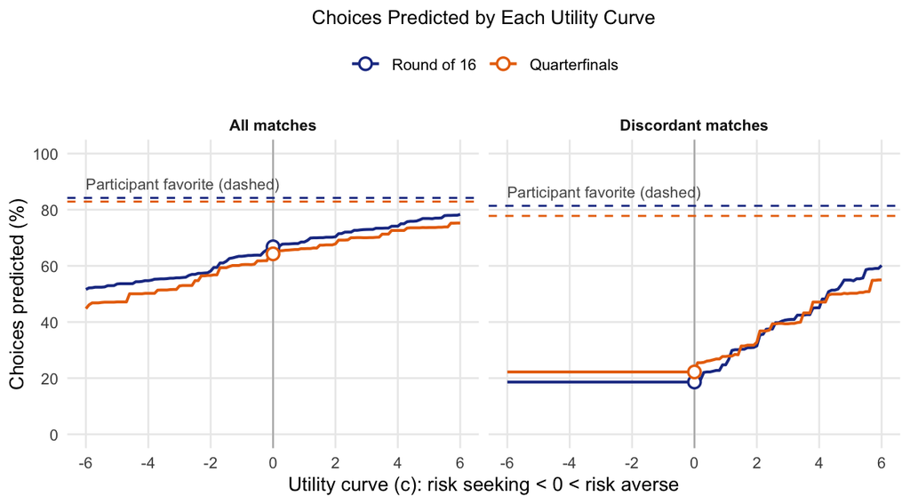

Choices Predicted per Participant by Expected Value, Expected Utility, and the Participant Favorite

|  | Round of 16 M (SD) of 8 | Round of 16 % | Quarterfinals M (SD) of 4 | Quarterfinals % |
| --- | --- | --- | --- | --- |
| EV (risk neutral) | 5.34 (1.81) | 66.8 | 2.57 (1.13) | 64.3 |
| EU, one curve for every participant (c = 6) | 6.27 (1.70) | 78.3 | 3.01 (1.03) | 75.2 |
| EU, each participant's best curve (in-sample) | 6.45 (1.59) | 80.7 | 3.21 (0.95) | 80.1 |
| EU, each participant's best curve (cross-validated) | 5.80 (1.68) | 72.5 | 2.72 (1.02) | 68.1 |
| Participant favorite | 6.74 (1.56) | 84.2 | 3.32 (1.02) | 82.9 |

Note: Best curve = the curve or curves among the 120 that predict the most of a participant's choices; in-sample estimates cannot fall below EV. Cross-validated = each choice predicted from the best curve for the participant's other choices (ties go to the curve closest to EV).

Choosing a curve for each participant (Table 14) improves prediction in-sample by construction, because the best curve can never predict fewer choices than EV. Predicting each choice from the curve that best fit the participant’s other choices improved on EV only slightly (R16: *M* = 5.80 vs. 5.34 of 8, *p* < .001; QF: *M* = 2.72 vs. 2.57 of 4, *p* < .001; Wilcoxon signed-rank tests) and remained below the participant favorite (6.74 and 3.32). A participant’s best curves were all risk averse for 61.1% of R16 and 46.1% of QF participants, all risk seeking for 0.0% and 0.0%, and no better than EV for 38.9% and 53.9%, including participants with no discordant matches, for whom no risk-averse curve can change a prediction.

Thus, risk aversion moved EU predictions toward participants’ choices, but only at high levels. The most risk-averse curve in the range considered (*c* = 6) closed 66% (R16) and 59% (QF) of the gap between EV and the participant favorite and predicted 60.2% and 55.0% of choices in discordant matches, compared with the 81.4% and 77.8% of choices that were on the predicted winner. Explaining the remaining choices requires risk aversion so strong that payoffs barely matter, which is equivalent to betting on the team expected to advance. Participants’ choices are therefore consistent with a strongly risk-averse utility function but not with moderate risk aversion, and these choices cannot distinguish strong risk aversion from a focus on predicting winners.

# Appendix A: Statistical Details

**Interpreting American odds.** American odds express profit relative to the stake, excluding the return of the stake. Negative odds (e.g., -140) mark the favorite: a 140-token bet returns 100 tokens of profit. Positive odds (e.g., +130) mark the underdog: a 100-token bet returns 130 tokens of profit. Implied probability = |odds| / (|odds| + 100) for negative odds and 100 / (odds + 100) for positive odds. The two teams’ implied probabilities sum to more than 1 (the vig); sportsbook probabilities in the analyses divide each team’s implied probability by the two teams’ sum. In each match the sportsbook favorite is the team with the lower American odds; the U.S. is treated as the sportsbook favorite against Belgium (both -110), so the U.S. and Belgium are each .50. EV per 100 tokens from the participant’s own stated probability p: EV = p x (100 + profit) - 100, where profit = 100 x 100/|odds| for negative odds and equals the odds for positive odds.

**Odds conditions and favorites.** Early Odds (data label “American Odds Condition”) = anchored, odds shown while predicting; Late Odds (“No Odds Condition”) = unanchored, odds shown only when betting. Sections 1 and 2 compare the conditions; Sections 3 and 4 pool them. The participant favorite is the team the participant predicted to advance (Block 1 pick); the sportsbook favorite is defined above.

**Probability estimates and anchoring.** Per-match Welch t-tests compare the probability anchored and unanchored participants assigned to the sportsbook favorite (the underdog’s is its complement); Holm correction across the 12 matches; d with pooled SD. Deviation = participant probability for the sportsbook favorite - sportsbook probability, in percentage points. Condition differences in absolute and signed deviation use linear mixed models, and the share of estimates within 2 points uses a logistic mixed model, all with match fixed effects and a participant random intercept. The share of participant favorites that were the sportsbook favorite is compared by logistic mixed models (participant random intercept), overall and by match outcome. The scatterplot (Appendix C) shows participant vs. sportsbook probability with linear fits; the slope difference is the sportsbook x condition interaction in a linear mixed model (participant random intercept; Satterthwaite df).

**Brier scores.** A participant’s Brier score is the mean over matches of the squared difference between the probability assigned to a team and the outcome (1 if it advanced, 0 otherwise). Within a match, the mean individual Brier score equals (mean probability - outcome)^2 + variance of probabilities across participants: collective error + dispersion (Krogh & Vedelsby, 1994). Exact; no probability bins; invariant to which team is labeled the event. 95% CIs from a cluster bootstrap (2,000 resamples of participants, keeping each participant’s matches together). Condition differences in mean Brier score use Welch t-tests. Reference strategies: always 50/50; always back the sportsbook favorite with certainty (U.S. counted as the favorite); the de-vigged sportsbook probability. Correlations: Pearson, mean Brier score with final tokens and number of bets won.

**Expected value analyses.** Team-level rows (mean EV, % positive) use participant x team evaluations with team fixed effects; match-level rows use participant x match observations with match fixed effects; all have a participant random intercept (linear for EV, logistic for percentages). Higher-EV team = team with the larger EV from the participant’s own probability; estimates with equal EVs (50% for the U.S. at -110/-110) are excluded. Discordant match = the participant favorite is not the higher-EV team.

**Repeated-measures correlations.** Each variable is centered within participant and the centered values are pooled (Bakdash & Marusich, 2017); df = observations - participants - 1. Correlations with binary variables are point-biserial. Holm correction across the 15 pairs within each sample. R16 below the diagonal, QF above.

**Models of betting on the sportsbook favorite.** Outcome = Block 3 bet on the sportsbook favorite (1) vs. underdog (0). Mixed-effects logistic regressions (glmer) with a participant random intercept; continuous predictors standardized within sample. Payoff SD of a 100-token bet = (profit + 100) x sqrt(p(1 - p)). The combined model replaces the probability with the binary participant favorite = sportsbook favorite (less collinear with the EV difference) and adds odds condition as a covariate; VIFs from linear regressions among the predictors. Relative importance = general dominance weights (Luo & Azen, 2013) on marginal R2 (Nakagawa & Schielzeth, 2013; fixed-effect variance / (fixed + random-intercept + pi^2/3)), over all subsets of the five predictors, reported as % of the full-model marginal R2. % classified from the fixed effects only (log-odds > 0).

**Bet distribution profiles.** Normalized HHI = (HHI - 1/k)/(1 - 1/k), k = 8 (R16) or 4 (QF); participants who wagered no tokens are excluded. Strategy value = normalized HHI of half the tokens on one match and the rest spread evenly. Within each sample, bettors were split 80/20 (seeded) into training and testing sets; normalized HHI and proportion of matches bet on were standardized with training moments; k-means (50-100 starts) for k = 2 to 6; k = 3 chosen from variance explained and average silhouette width. A depth-3 CART tree (minimum node size 15) fitted to the training clusters gives threshold rules, evaluated in the testing set and then applied to all bettors. Stability = mean Jaccard similarity of each training cluster across 200 bootstrap re-clusterings (Hennig, 2007). Group differences use one-way ANOVAs (partial eta-squared) and Games-Howell post hoc tests.

**Tokens on the participant favorite vs. the higher-EV team.** Option A: discordant matches with a bet of at least one token; tokens per bet compared between bets on the participant favorite and on the higher-EV team with a linear mixed model (participant random intercept). Option B: per participant, total tokens on participant favorites and on higher-EV teams across all matches, compared with a paired t-test. Both use the final bet and token amount; matches with equal EVs are excluded.

**Expected utility analyses.** Choices are Block 3 bets (8 per R16 participant and 4 per QF participant). Each team’s gamble is a 100-token bet that returns 100 + profit tokens with the participant’s stated probability and 0 otherwise; the full 100-token budget gives the curvature of the utility function its largest effect, so a smaller stake would require more risk aversion to change a choice. Utility: u(x) = (1 - exp(-cx/900))/(1 - exp(-c)), with u(0) = 0 and u(900) = 1, equivalent to 1 - exp(-x/R) with R = 900/c; 120 curves, c = -6 to 6 by 0.1. A choice is correctly predicted when the chosen bet’s EU is at least the other bet’s. Participant favorite = Block 1 pick. Per participant, the best curves are those predicting the most choices; the participant is classified as EV if EV predicts as many choices as the best curve, risk averse if all best curves have c > 0, risk seeking if all have c < 0, and mixed otherwise. Cross-validation leaves out one match, selects the best curve on the remaining matches (ties go to the curve closest to c = 0, including EV), and predicts the omitted choice. The break-even c in a discordant match is the root of EU(favorite) = EU(underdog); EU predicts the predicted winner for any larger c, and there is no root when the participant gave 50%. Unlimited risk aversion is evaluated at c = 200. Per-participant counts are compared with paired Wilcoxon signed-rank tests.

# Appendix B: Supplementary Tables

Correlation and Slope Between Sportsbook and Participant Probabilities by Odds Condition

|  | Round of 16 | Quarterfinals |
| --- | --- | --- |
| r, anchored | .34 | .21 |
| r, unanchored | .25 | .13 |
| Slope, anchored | .59 | 1.19 |
| Slope, unanchored | .41 | .66 |
| Slope difference (anchored - unanchored) [95% CI] | .17 [.08, .27] | .52 [.14, .91] |
| t (df) | 3.68 (3505) | 2.64 (1501) |
| p | <.001 | .008 |

Note: Slopes from a linear mixed model of participant probability on sportsbook probability, odds condition, and their interaction, with a random intercept for participant. A slope of 1 is one-for-one tracking of the sportsbook.

Deviation of Probability Estimates From the Sportsbook by Odds Condition

|  | Anchored M (SD) or % | Unanchored M (SD) or % | Anchored vs. Unanchored [95% CI] | p |
| --- | --- | --- | --- | --- |
| **Round of 16** |  |  |  |  |
| Absolute deviation (percentage points) | 15.2 (15.7) | 17.3 (14.6) | -2.11 [-3.62, -0.60] | .006 |
| Signed deviation (participant - sportsbook, percentage points) | -3.9 (21.5) | -6.0 (21.8) | 2.05 [0.30, 3.81] | .022 |
| Estimate within 2 percentage points of the sportsbook (%) | 14.5 | 10.0 | 1.60 [1.27, 2.02] | <.001 |
| **Quarterfinals** |  |  |  |  |
| Absolute deviation (percentage points) | 17.6 (14.9) | 17.2 (13.7) | 0.42 [-1.27, 2.12] | .624 |
| Signed deviation (participant - sportsbook, percentage points) | -7.6 (21.8) | -8.7 (20.2) | 1.07 [-1.44, 3.59] | .404 |
| Estimate within 2 percentage points of the sportsbook (%) | 9.0 | 9.0 | 1.00 [0.72, 1.39] | .990 |

Note: Deviations are in percentage points. Estimates come from mixed models with match fixed effects and a participant random intercept: linear coefficients (anchored - unanchored) for deviations, odds ratios for percentages.

Percentage of Participant Favorites That Were the Sportsbook Favorite by Odds Condition and Match Outcome

|  | Anchored (%) | Unanchored (%) | OR [95% CI] | p |
| --- | --- | --- | --- | --- |
| **Round of 16** |  |  |  |  |
| All matches | 75.4 | 74.0 | 1.12 [0.92, 1.36] | .254 |
| Matches the sportsbook favorite advanced | 75.0 | 71.0 | 1.29 [1.01, 1.65] | .043 |
| Matches the sportsbook underdog advanced | 76.2 | 79.0 | 0.84 [0.63, 1.12] | .241 |
| **Quarterfinals** |  |  |  |  |
| All matches | 72.5 | 74.9 | 0.88 [0.65, 1.19] | .403 |

Note: Odds ratios (anchored vs. unanchored) from mixed logistic regressions with a participant random intercept. Sportsbook underdogs advanced in USA vs. Belgium, Brazil vs. Norway, Switzerland vs. Colombia (Round of 16); sportsbook favorites advanced in every quarterfinal. Condition x outcome interaction in Round of 16: OR = 1.48, p = .014.

Choosing the Number of Bet Amount Groups (Training Sets)

| k | Round of 16 Variance explained (%) | Round of 16 Gain (points) | Round of 16 Avg. silhouette | Quarterfinals Variance explained (%) | Quarterfinals Gain (points) | Quarterfinals Avg. silhouette |
| --- | --- | --- | --- | --- | --- | --- |
| 2 | 68.1 | - | .72 | 79.0 | - | .87 |
| 3 | 84.9 | +16.8 | .69 | 88.6 | +9.6 | .81 |
| 4 | 89.9 | +5.0 | .67 | 93.6 | +5.0 | .80 |
| 5 | 94.6 | +4.7 | .71 | 95.4 | +1.8 | .72 |
| 6 | 95.8 | +1.2 | .65 | 97.3 | +2.0 | .73 |

Training/Testing Split, Rule Recovery in Testing Data, and Cluster Stability

|  | Round of 16 | Quarterfinals |
| --- | --- | --- |
| Bettors (n) | 496 | 496 |
| Training set (n) | 397 | 397 |
| Testing set (n) | 99 | 99 |
| Holdout participants whose group the tree rules reproduce (%) | 96.0 | 99.0 |
| Jaccard, Spreaders | .98 | .98 |
| Jaccard, Selectors | .93 | .78 |
| Jaccard, Concentrators | .95 | .96 |

Decision Tree Rules (branch conditions; node group shown at leaves)

| Node | Branch condition | Leaf group |
| --- | --- | --- |
| **Round of 16** |  |  |
| 2 | prop_matches_bet>=0.6875 | Spreaders |
| 3 | prop_matches_bet< 0.6875 |  |
| 6 | hhi_norm< 0.6029 | Selectors |
| 7 | hhi_norm>=0.6029 | Concentrators |
| **Quarterfinals** |  |  |
| 2 | prop_matches_bet>=0.875 | Spreaders |
| 3 | prop_matches_bet< 0.875 |  |
| 6 | hhi_norm< 0.6408 | Selectors |
| 7 | hhi_norm>=0.6408 | Concentrators |

Risk Attitude of the Exponential Utility Curves

| c | Risk tolerance R (tokens) | u(450) | CE: 50-50 gamble, 0 or 900 | CE: 50-50 gamble, 0 or 200 |
| --- | --- | --- | --- | --- |
| -6 | -150 | .047 | 796 | 131.1 |
| -3 | -300 | .182 | 707 | 116.4 |
| -1 | -900 | .378 | 558 | 105.5 |
| 0 | Infinite | .500 | 450 | 100.0 |
| 1 | 900 | .622 | 342 | 94.5 |
| 3 | 300 | .818 | 193 | 83.6 |
| 6 | 150 | .953 | 104 | 68.9 |
| 10 | 90 | .993 | 62 | 53.1 |
| 20 | 45 | 1.000 | 31 | 30.7 |

Note: u(x) = (1 - exp(-cx/900))/(1 - exp(-c)), equivalently 1 - exp(-x/R) with R = 900/c. u(450) is the reference-lottery probability: the chance of 900 tokens (otherwise 0) that makes the lottery equivalent to 450 tokens for sure. CE = certainty equivalent in tokens; a risk-neutral bettor (c = 0) values each gamble at its EV (450 and 100). The second gamble is an even-money 100-token bet.

# Appendix C: Supplementary Figures

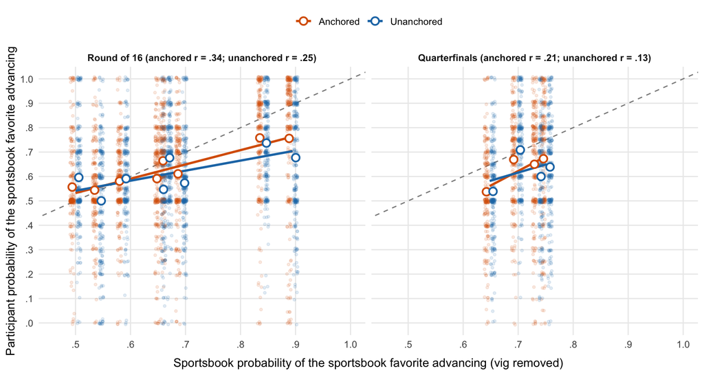

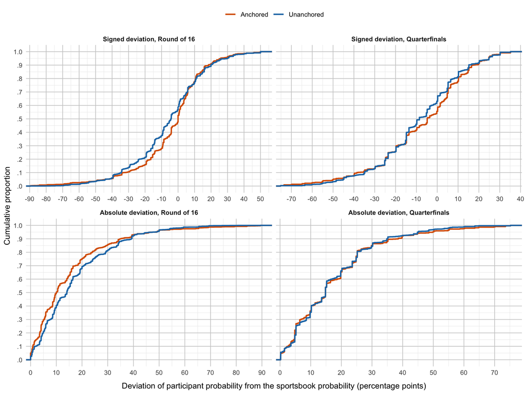